# Accuracy of aphylo

George G Vega Yon

March 14, 2019

## Recap

Last time:

1. We ran a leave-one-out cross-validation algorithm in about 1,000 function-tree pairs
2. Implemented function to calculate AUCs for our data (the AUC R package wasn’t the best option for us)
3. Will look at best and worse cases considering more than one annotation of 0/1 each.
4. This will include reporting average shortest path lengths between pairs (more later).

Today:

1. Look at our Prediction Score function (AUCs actually are not very good when predictions are around 50%)
2. Look at individual predictions (and functions/trees for fun).

## Overall fitness

Prediction score

$$\begin{equation*}
\delta = \sum_{n: z_{n}{} \in \{0, 1\}}(z_{n}{} - \hat x_{n})^2
\end{equation*}$$

Which is a special case of the statistic described in the appendix when we assume no correlation across leafs, and a single function. Moreover, assuming that $\hat x_{n}\sim \mbox{Bernoulli}(\alpha)$, the statistic has an expectation equal to:

$$\begin{equation*}
{\mathbb{E}\left\{\sum_{n: z_{n}{} \in \{0, 1\}}(z_{n}{} - \hat x_{n})^2\vphantom{\mathbf{Z}{}}\right|\left.\vphantom{\sum_{n: z_{n}{} \in \{0, 1\}}(z_{n}{} - \hat x_{n})^2}\mathbf{Z}{}\right\}} = \sum_{n: z_{n}{} \in \{0, 1\}}{\mathbb{E}\left\{(z_{n}{} - \hat x_{n})^2\vphantom{\mathbf{Z}{}}\right|\left.\vphantom{(z_{n}{} - \hat x_{n})^2}\mathbf{Z}{}\right\}} = \sum_{n: z_{n}{} \in \{0, 1\}}(z_{n}{} - \alpha)^2
\end{equation*}$$

Finally, in order to improve interpretability, we normalize this statistic by the value it acquires in the worse case scenario, this is, when $\hat x_{n} = 1 - z_{n}{}$, then its value equals

$$\begin{equation*}
\sum_{n: z_{n}{} \in \{0, 1\}}(z_{n}{} - (1 - z_{n}{}))^2 = \sum_{n: z_{n}{} \in \{0, 1\}} 1 = |{n: z_{n}{} \in \{0, 1\}}|
\end{equation*}$$

Which we denote as $\underline{\delta}$. The normalized $\delta$ ranges from 0, perfect prediction, to 1, complete miss match.

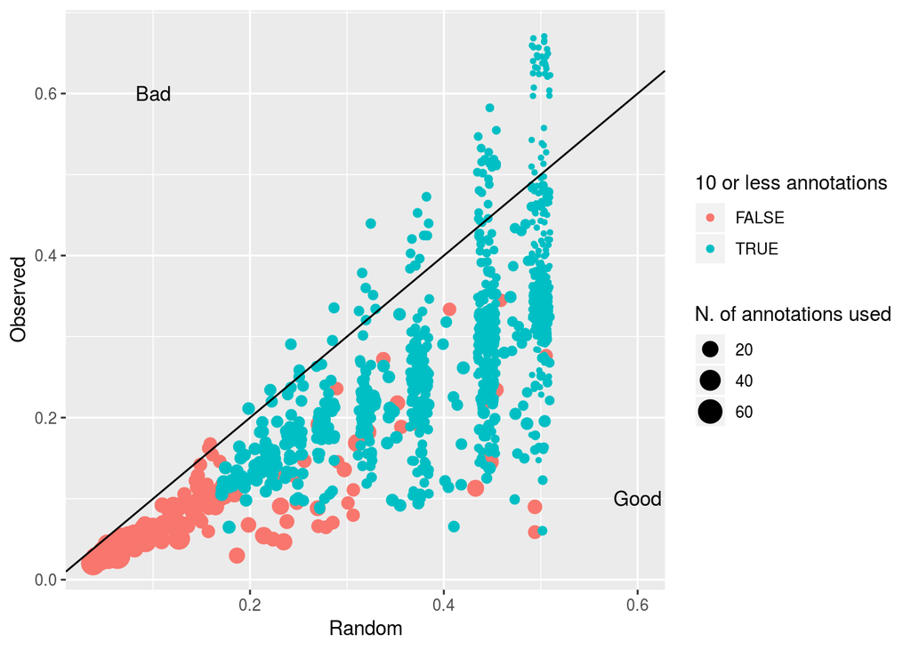

## What characterizes a better performance?

Statistical models

|  | **Obs** | **Rand** | **1(Obs < Random)** | **Rand - Obs** |  |
| --- | --- | --- | --- | --- | --- |
| (Intercept) | 0.25*** | 0.33*** | 2.43* | -0.08*** |  |
|  | (0.01) | (0.01) | (0.96) | (0.01) |  |
| `0` | -0.05*** | -0.01*** | -0.50 | -0.04*** |  |
|  | (0.01) | (0.00) | (0.72) | (0.00) |  |
| `1` | -0.01*** | -0.01*** | 0.02 | 0.00*** |  |
|  | (0.00) | (0.00) | (0.13) | (0.00) |  |
| prop0s | 0.36*** | 0.36*** | -0.33 | 0.00 |  |
|  | (0.03) | (0.02) | (1.60) | (0.02) |  |
| size | -0.00*** | -0.00*** | -0.00 | -0.00* |  |
|  | (0.00) | (0.00) | (0.00) | (0.00) |  |
| `0`:size | 0.00*** | 0.00*** | 0.00 | 0.00* |  |
|  | (0.00) | (0.00) | (0.00) | (0.00) |  |
| `1`:size | 0.00*** | 0.00*** | 0.00 | -0.00 |  |
|  | (0.00) | (0.00) | (0.00) | (0.00) |  |
| AIC | -2122.90 | -3167.03 | 587.95 | -2214.92 |  |
| BIC | -2083.09 | -3127.21 | 622.78 | -2175.11 |  |
| Log Likelihood | 1069.45 | 1591.51 | -286.97 | 1115.46 |  |
| Deviance | 8.51 | 3.21 | 573.95 | 7.81 |  |
| Num. obs. | 1071 | 1071 | 1071 | 1071 |  |
| p < 0.001, p < 0.01, p < 0.05 |  |  |  |  |  |

## Trees with the most annotated leafs

Average inverse (undirected) shortest path length

$$\begin{equation}
S = |J|^{-1}\sum_{(i,j) \in J}g(i, j)^{-1}
\end{equation}$$

Where $g(i,j)$ is the shortest path length between the pair $(i,j)$.

## Trees with the most annotated leafs (cont.)

Best and worst prediction cases. The data included here has at least 4 annotations. A case is classified as bad if the random prediction score was lower than the observed prediction score.

| tree | term | 0 | 1 | 9 | annotated | auc | pscore_obs | pscore_rand | bad |
| --- | --- | --- | --- | --- | --- | --- | --- | --- | --- |
| PTHR10788 | GO:0004805 | 6 | 6 | 376 | 12 | 1 | 0.06 | 0.50 | FALSE |
| PTHR43903 | GO:0060080 | 2 | 2 | 340 | 4 | 1 | 0.06 | 0.50 | FALSE |
| PTHR10788 | GO:0003825 | 6 | 8 | 374 | 14 | 1 | 0.09 | 0.49 | FALSE |
| PTHR31682 | GO:0052691 | 2 | 3 | 101 | 5 | 1 | 0.10 | 0.48 | FALSE |
| PTHR10438 | GO:0080058 | 2 | 2 | 502 | 4 | 1 | 0.12 | 0.50 | FALSE |
| PTHR10209 | GO:0052634 | 2 | 5 | 2169 | 7 | 1 | 0.07 | 0.41 | FALSE |
| PTHR10961 | GO:0051700 | 2 | 2 | 231 | 4 | 1 | 0.16 | 0.50 | FALSE |
| PTHR10082 | GO:0007179 | 2 | 2 | 442 | 4 | 1 | 0.16 | 0.50 | FALSE |
| PTHR10082 | GO:0043149 | 2 | 2 | 442 | 4 | 1 | 0.16 | 0.50 | FALSE |
| PTHR12419 | GO:0016579 | 2 | 2 | 726 | 4 | 1 | 0.16 | 0.50 | FALSE |
| PTHR42738 | GO:0005739 | 1 | 4 | 207 | 5 | 0 | 0.44 | 0.32 | TRUE |
| PTHR11700 | GO:0005829 | 1 | 3 | 329 | 4 | 0 | 0.47 | 0.38 | TRUE |
| PTHR10648 | GO:0005829 | 1 | 3 | 399 | 4 | 0 | 0.45 | 0.38 | TRUE |
| PTHR43322 | GO:0008661 | 1 | 3 | 125 | 4 | 0 | 0.44 | 0.38 | TRUE |
| PTHR11451 | GO:0002161 | 1 | 4 | 359 | 5 | 0 | 0.38 | 0.32 | TRUE |
| PTHR11451 | GO:0006435 | 1 | 5 | 358 | 6 | 0 | 0.34 | 0.28 | TRUE |
| PTHR32315 | GO:0003999 | 1 | 3 | 121 | 4 | 0 | 0.42 | 0.38 | TRUE |
| PTHR10670 | GO:0008622 | 1 | 3 | 158 | 4 | 0 | 0.42 | 0.38 | TRUE |
| PTHR11941 | GO:0005777 | 1 | 3 | 723 | 4 | 0 | 0.42 | 0.38 | TRUE |
| PTHR11964 | GO:0005829 | 1 | 6 | 349 | 7 | 0 | 0.29 | 0.24 | TRUE |

## Best 4 (1/4)

[figure not shown]

Expected and Predicted Probabilities Tree: PTHR10788, Function: GO:0004805

| Expected | Predicted |
| --- | --- |
| 0 | 0.1224948 |
| 0 | 0.1235448 |
| 0 | 0.2204797 |
| 0 | 0.2379189 |
| 0 | 0.2626701 |
| 0 | 0.2692525 |
| 1 | 0.6441137 |
| 1 | 0.6519001 |
| 1 | 0.7227600 |
| 1 | 0.7385348 |
| 1 | 0.8644758 |
| 1 | 0.8745585 |

## Best 4 (2/4)

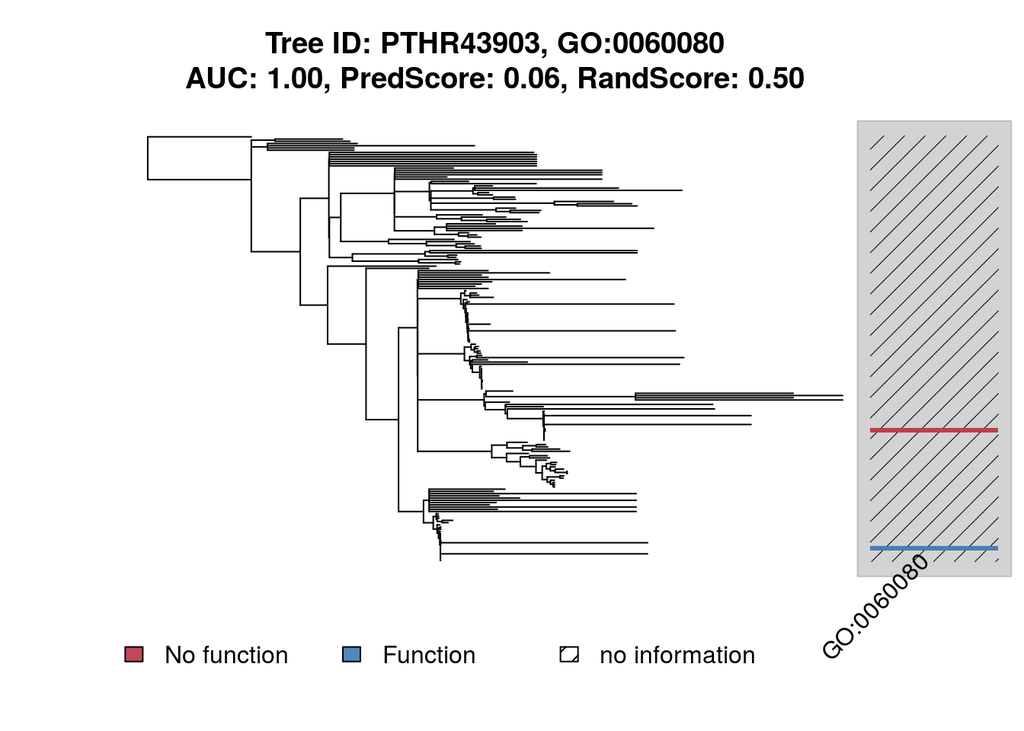

Expected and Predicted Probabilities Tree: PTHR43903, Function: GO:0060080

| Expected | Predicted |
| --- | --- |
| 0 | 0.2312482 |
| 0 | 0.2432008 |
| 1 | 0.7450150 |
| 1 | 0.7473239 |

## Best 4 (3/4)

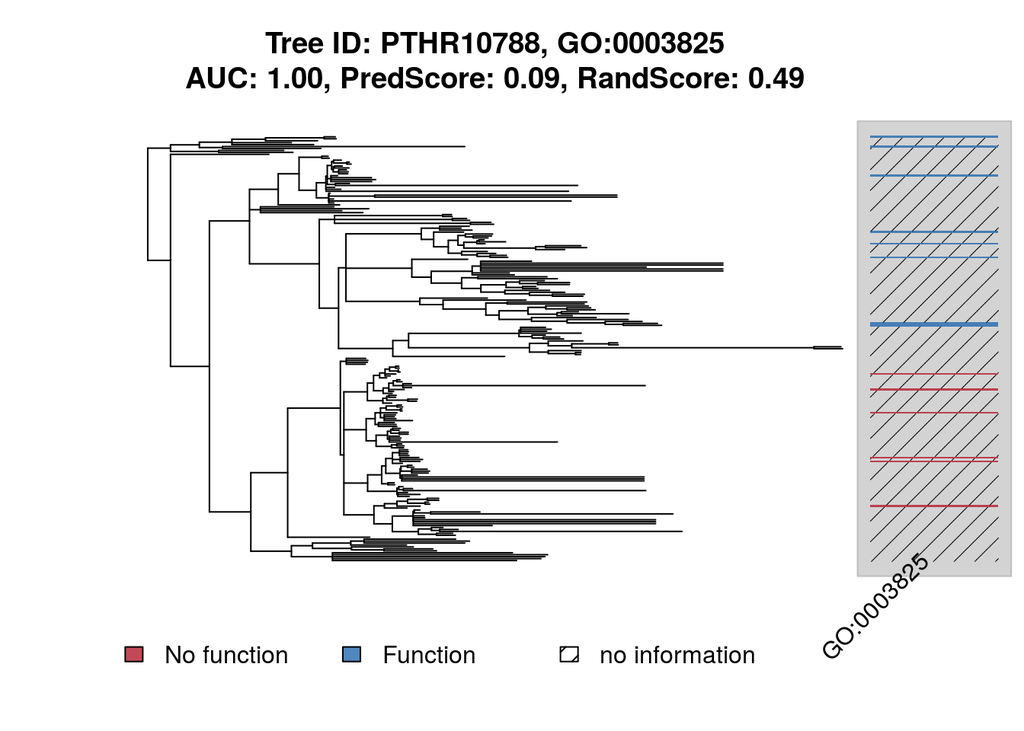

Expected and Predicted Probabilities Tree: PTHR10788, Function: GO:0003825

| Expected | Predicted |
| --- | --- |
| 0 | 0.1416906 |
| 0 | 0.1550975 |
| 0 | 0.2709311 |
| 0 | 0.2752791 |
| 0 | 0.3014502 |
| 0 | 0.3039647 |
| 1 | 0.4599398 |
| 1 | 0.5294387 |
| 1 | 0.5645045 |
| 1 | 0.7634373 |
| 1 | 0.7783518 |
| 1 | 0.7968782 |
| 1 | 0.8695324 |
| 1 | 0.8764516 |

## Best 4 (4/4)

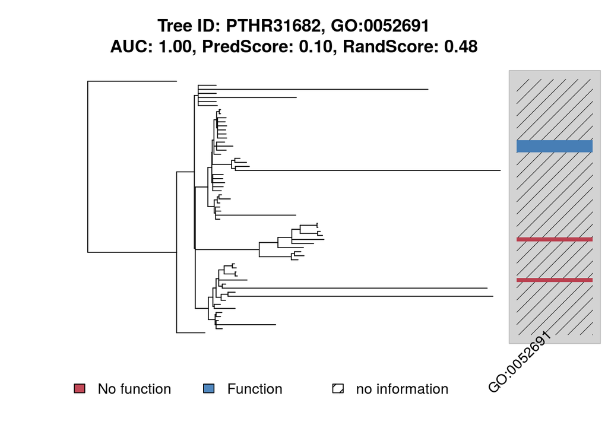

Expected and Predicted Probabilities Tree: PTHR31682, Function: GO:0052691

| Expected | Predicted |
| --- | --- |
| 0 | 0.4626452 |
| 0 | 0.4671376 |
| 1 | 0.8524634 |
| 1 | 0.8530320 |
| 1 | 0.8601610 |

## Worse 4 (1/4)

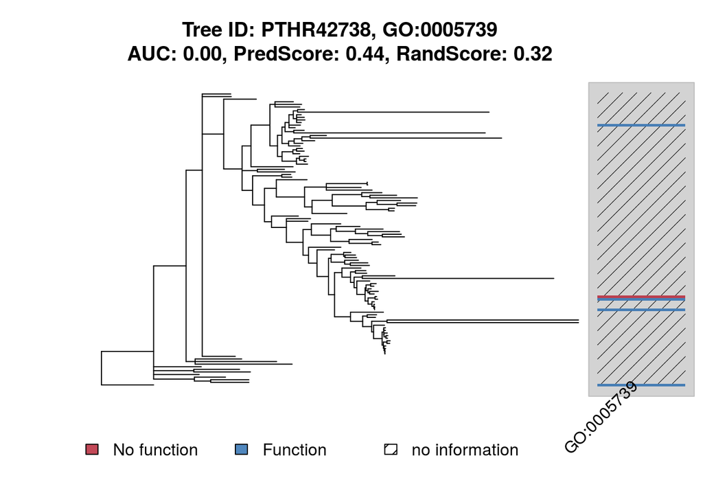

Expected and Predicted Probabilities Tree: PTHR42738, Function: GO:0005739

| Expected | Predicted |
| --- | --- |
| 1 | 0.1985000 |
| 1 | 0.3556953 |
| 1 | 0.5662764 |
| 1 | 0.5765555 |
| 0 | 0.8789859 |

## Worse 4 (2/4)

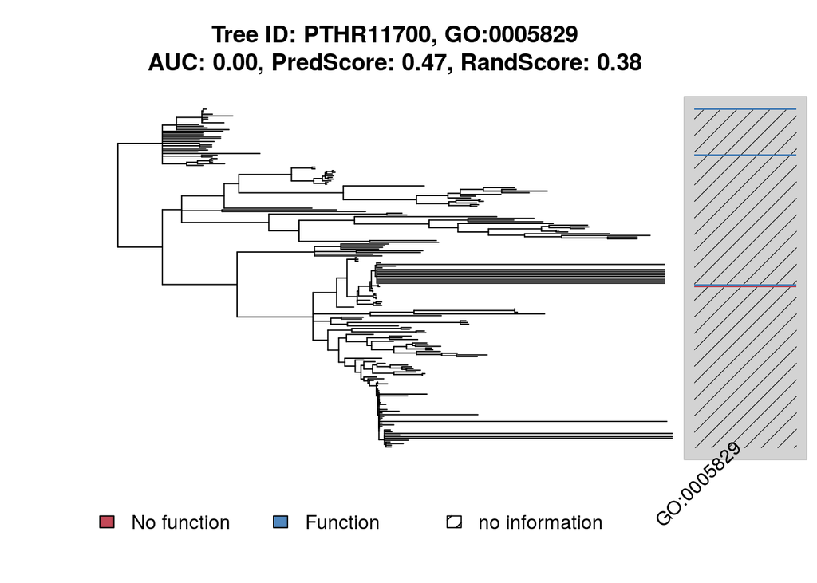

Expected and Predicted Probabilities Tree: PTHR11700, Function: GO:0005829

| Expected | Predicted |
| --- | --- |
| 1 | 0.2461995 |
| 1 | 0.3910797 |
| 1 | 0.4732707 |
| 0 | 0.8209731 |

## Worse 4 (3/4)

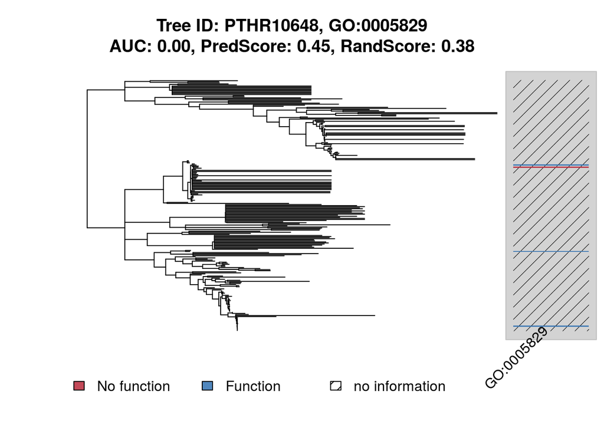

Expected and Predicted Probabilities Tree: PTHR10648, Function: GO:0005829

| Expected | Predicted |
| --- | --- |
| 1 | 0.2397763 |
| 1 | 0.4129222 |
| 1 | 0.5334451 |
| 0 | 0.8186869 |

## Worse 4 (4/4)

[figure not shown]

Expected and Predicted Probabilities Tree: PTHR43322, Function: GO:0008661

| Expected | Predicted |
| --- | --- |
| 1 | 0.2292145 |
| 1 | 0.4644495 |
| 1 | 0.5329565 |
| 0 | 0.8123327 |